# Background

In this assignment, convolutional neural networks (CNNs) are built to classify whether images contain a dog (1) or cat(0). To facilitate building the neural networks, a 2x2 design is considered to test the impact of different hyperparamters. The training set contains 25,000 images, while the test set contains 12,500 images. The test set predictions have a goal of being submitted to Kaggle for scoring. The tflearn package is used to generate models due to its brevity. Commentary is provided at the end of the assignment on the best model to use for image classification.

# Data Initation and Preparation

In this section, we read in the data and prepare it for modeling. Along the way, checks are performed to ensure that the data is read in properly.

```python
RANDOM_SEED = 42

import warnings
warnings.filterwarnings("ignore")

# import packages
import numpy as np
import pandas as pd
import matplotlib.pyplot as plt
import seaborn as sns

# for model building and results
import tensorflow as tf

# for display
from prettytable import PrettyTable

# for reading in pictures
import cv2
from tqdm import tqdm
```

Some extra work is needed to read in this data, as .jpg images are provided for each picture. Therefore, to read the data in, we will also need to classify each picture as cat (0) or dog (1).

To start the process, we examine the names of each .jpg file.

```python
import os
print(os.listdir("/Users/juliaellis/Documents/NU/422 - Machine Learning/R Code/dogs-vs-cats/train"))
```

```
['cat.0.jpg', 'cat.1.jpg', 'cat.10.jpg', 'cat.100.jpg', 'cat.1000.jpg', 'cat.10000.jpg', 'cat.10001.jpg', 'cat.10002.jpg', 'cat.10003.jpg', 'cat.10004.jpg', 'cat.10005.jpg', 'cat.10006.jpg', 'cat.10007.jpg', 'cat.10008.jpg', 'cat.10009.jpg', 'cat.1001.jpg', 'cat.10010.jpg', 'cat.10011.jpg', 'cat.100…
```

Based on the naming convetion shown above, we can see that we can easily code each picture that has 'cat' in the name as a 0, and each picture that has 'dog' in the name as a 1. Additionally, in reading in the data, we resize each image to a more managemeable size (64 x 64) and standardize the data by dividing by 255. We can normalize the data this way to get all values scaled between 0-1. Therefore, to read in all pictures, we need to loop through each one to perform these computations.

```python
main_dir = "/Users/juliaellis/Documents/NU/422 - Machine Learning/R Code"
train_dir = "dogs-vs-cats/train"
train_path = os.path.join(main_dir,train_dir)

#https://www.kaggle.com/shrawansapre/dogs-vs-cats-convolutional-neural-nets
label=[]
data=[]

#Loop iterating over each file in the training folder
for file in tqdm(os.listdir(train_path)):
    #Reading every image and converting it to grayscale
    image=cv2.imread(os.path.join(train_path,file), cv2.IMREAD_GRAYSCALE)
    #Resizing the image into a manageable size
    image=cv2.resize(image,(64,64))
    #If a file name starts with "cat"
    if file.startswith("cat"):
        label.append(0)
    elif file.startswith("dog"):
        label.append(1)
    try:
        data.append(image/255)
    except:
        label=label[:len(label)-1]
```

```python
#Converting our data and labels into numpy arrays
X_train=np.array(data)
y_train=np.array(label)

print (X_train.shape)
print (y_train.shape)
```

```
(25000, 64, 64)
(25000,)
```

As a quick check that we have loaded in all the data successfully, we display a random image along with its classification.

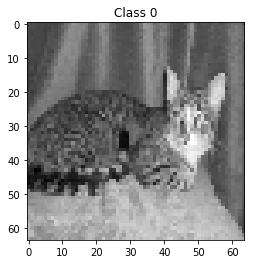

```python
#Displaying the 10th image along with the class it belongs to

plt.imshow(X_train[9], cmap='gray')
plt.title('Class '+ str(y_train[9]))
```

From the picture above, we can see that we have been successful in loading in the data, as we have a cat picture that is appropriately labeled as a cat.

As a final step, we reshape the data into arrays to avoid data shape errors in modeling.

```python
#Reshaping our data from a 64x64 array into a 64,64,1 array
X_train = X_train.reshape((X_train.shape)[0],(X_train.shape)[1],(X_train.shape)[2],1)
y_train.shape = (-1, 1) #have to do this; otherwise get errors during model building
print(X_train.shape)
print(y_train.shape)
```

```
(25000, 64, 64, 1)
(25000, 1)
```

We repeat the data load process for the test data set as well. Therefore, minimal commentary is provided. The only difference with reading in the test set data is that an id value is captured for each picture that is loaded. This id value is used when generating predictions.

```python
#read in test data
main_dir = "/Users/juliaellis/Documents/NU/422 - Machine Learning/R Code"
test_dir = "dogs-vs-cats/test1"
test_path = os.path.join(main_dir,test_dir)

#https://www.kaggle.com/shrawansapre/dogs-vs-cats-convolutional-neural-nets
data=[]
id_val=[]
#Loop iterating over each file in the training folder
for file in tqdm(os.listdir(test_path)):
    id_val.append((file.split("."))[0])
    #Reading every image and converting it to grayscale
    image=cv2.imread(os.path.join(test_path,file), cv2.IMREAD_GRAYSCALE)
    #Resizing the image into a manageable size
    image=cv2.resize(image,(64,64))
    data.append(image/255)
```

```python
#Converting our data into a numpy array
X_test=np.array(data)

print(X_test.shape)
```

```
(12500, 64, 64)
```

```python
#Need the same format as train data
X_test = X_test.reshape((X_test.shape)[0],(X_test.shape)[1],(X_test.shape)[2],1)
print(X_test.shape)
```

```
(12500, 64, 64, 1)
```

Before we dive into modeling, there are a few additional checks that shoiuld be performed.

First, we verify that our data set truly has values between 0 and 1. We pick the first entry to help verify.

```python
print("Max value is: ", np.max(X_train[0]))
print("Min value is: ", np.min(X_train[0]))
```

```
Max value is:  0.9176470588235294
Min value is:  0.00784313725490196
```

From the output above, we can see that the first entry has a min value just above 0 and a max value just below 1. Therefore, our data standardization has been performed successfully. Next, we examine the distribution of cats and dogs.

```python
num_zeros = (y_train == 0).sum()
num_ones = (y_train == 1).sum()
print("The number of cats is: ", num_zeros)
print("The number of dogs is: ", num_ones)
```

```
The number of cats is:  12500
The number of dogs is:  12500
```

We can see that there is a 50/50 split of cat and dog images, which is a good sign. Otherwise, work would have had to be done to create a more even class distribution, which would help ensure we generate an unbiased model.

Given we have read in all 25,000 train and 12,500 test images and verified that data standardization and the class distribution are sufficient for modeling, we are ready to move on to the model building phase.

# Model Building

In this assignment, a 2x2 factorial design is considered to test the performance of different hyperparameters within a CNN model.

For context/background, the overall architecture of a CNN consists of an input layer, hidden layer(s), and an output layer. One of the main building blocks of a CNN is the convolutional layer, which is a type of hidden layer whose main goal is to a receive a feature map. Convolutional layers help with the detection of low-level features within an image.

Because CNN models are complex and require a decent number of layers to have 'good' performance, some additional explanation is needed before moving forward.

First, in this assignment, all pooling layers used will be max pooling layers. This decision was made because "a max pooling layer is the most common type of pooling layer" (Geron, p. 372).

Second, after each convolutional layer, a max pooling layer is used. This decision was made to reduce dimensionality and help protect against overfitting.

Third, another overfitting technique that is used is a dropout layer, which drops unuseful neurons.

Fourth, the adam optimizer is used when fitting all models. This optimizer is a popular optimizer, and because it is not gradient descent, then processing times are reduced.

Below is a table that displays the experimental factors used in this assignment. The number of layers that are changed is removing a convolutional and max pooling layer (which are considered one layer).

```python
a = PrettyTable()
a.field_names = ["Model Name","Number of Layers","Learning Rate"]
a.add_row(["Model One",6,.0001])
a.add_row(["Model Two",6,.01])
a.add_row(["Model Three",7,.0001])
a.add_row(["Model Four",7,.01])
print(a.get_string(title="CNN Experimental Factors"))
```

```
+------------------------------------------------+
|            CNN Experimental Factors            |
+-------------+------------------+---------------+
|  Model Name | Number of Layers | Learning Rate |
+-------------+------------------+---------------+
|  Model One  |        6         |     0.0001    |
|  Model Two  |        6         |      0.01     |
| Model Three |        7         |     0.0001    |
|  Model Four |        7         |      0.01     |
+-------------+------------------+---------------+
```

## Baseline Model

```python
#https://mc.ai/cats-and-dogs-classifier-convolutional-neural-network-with-python-and-tensorflow-9-steps-of/
import tflearn
from tflearn.layers.conv import conv_2d, max_pool_2d
from tflearn.layers.core import input_data, dropout, fully_connected
from tflearn.layers.estimator import regression

MODEL_NAME = 'dogs-vs-cats-convnet-m2'
IMAGE_SIZE = 64
tf.reset_default_graph()

convnet = input_data(shape=[None, IMAGE_SIZE, IMAGE_SIZE, 1], name='input')

#Conv Layer 1
convnet = conv_2d(convnet, 32, 5, activation='relu')
convnet = max_pool_2d(convnet, 5)

#Conv Layer 2
convnet = conv_2d(convnet, 64, 5, activation='relu')
convnet = max_pool_2d(convnet, 5)

#Conv Layer 3
convnet = conv_2d(convnet, 128, 5, activation='relu')
convnet = max_pool_2d(convnet, 5)

#Conv Layer 4 - could also pull this
convnet = conv_2d(convnet, 64, 5, activation='relu')
convnet = max_pool_2d(convnet, 5)

#Conv Layer 5
convnet = conv_2d(convnet, 32, 5, activation='relu')
convnet = max_pool_2d(convnet, 5)

#Conv Layer 6
convnet = fully_connected(convnet, 1024, activation='relu')
convnet = dropout(convnet, 0.5)

#Fully Connected Layer with SoftMax as Activation Function
convnet = fully_connected(convnet, 1, activation='softmax')
#this is supposed to be a 2 here b/c we have 2 outputs but this throws an error below

#Regression for ConvNet with ADAM optimizer
convnet = regression(convnet, optimizer='adam', learning_rate=.0001, loss='categorical_crossentropy', name='targets')
convnet=tflearn.reshape(convnet,[-1]) #saw this online so adding this to see if it helps

model = tflearn.DNN(convnet, tensorboard_dir='log')
```

[output not shown]

```python
#adding this again to see if it helps at all
X = X_train.reshape(-1, 64, 64, 1)
y_train.shape = (-1, 1)
```

```python
# Train model for 3 epochs - using 3 to save time
# Keep getting this error and have tried resizing x, y...ValueError: Cannot feed value of shape (64, 1) for Tensor 'targets/Y:0', which has shape '(?, 2)'
# Redid output above to have a class of 1....but don't think this is quite right
model.fit(X, y_train, n_epoch=3,
    snapshot_step=500, show_metric=True, run_id=MODEL_NAME)
```

```
Training Step: 1217
| Adam | epoch: 003 | loss: 0.00000 - acc: 1.0000 -- iter: 25000/25000
Training Step: 1217
| Adam | epoch: 003 | loss: 0.00000 - acc: 1.0000 -- iter: 25000/25000
--
```

```python
model.save(MODEL_NAME) #good practice
```

```
INFO:tensorflow:./dogs-vs-cats-convnet-m2 is not in all_model_checkpoint_paths. Manually adding it.
```

```python
# generate predictions for the test set
predictions = model.predict(X_test)
```

```python
#check for predictions....which is why everything was seemingly wrong
def unique(list1):
    x = np.array(list1)
    print(np.unique(x))

unique(predictions) #only getting 1 here....hmmm....
```

```
[1.]
```

```python
predicted_val = [int(round(p[0])) for p in predictions] #round up if dog and down if cat, since predictions should be probabilities
submission_df = pd.DataFrame({'id':id_val, 'label':predicted_val}) #use the id val defined earlier
submission_df.to_csv("m1_v2_submission.csv", index=False)
```

## Remaining Models

Due to time constraints, this code has not been able to be executed. However, it is provided here to show directionally the next steps for the assignment.

To make it easier to generate the four models listed above, two functions are defined to aid in model building. The first function contains all layers, while the second function is the same as the full function except layer four has been removed.

```python
# define functions to build models
def cnn_model_full(IMAGE_SIZE, MODEL_NAME, LEARNING_RATE):
    tf.reset_default_graph()
    convnet = input_data(shape=[None, IMAGE_SIZE, IMAGE_SIZE, 1], name='input')

    #Conv Layer 1
    convnet = conv_2d(convnet, 32, 5, activation='relu')
    convnet = max_pool_2d(convnet, 5)

    #Conv Layer 2
    convnet = conv_2d(convnet, 64, 5, activation='relu')
    convnet = max_pool_2d(convnet, 5)

    #Conv Layer 3
    convnet = conv_2d(convnet, 128, 5, activation='relu')
    convnet = max_pool_2d(convnet, 5)

    #Conv Layer 4
    convnet = conv_2d(convnet, 64, 5, activation='relu')
    convnet = max_pool_2d(convnet, 5)

    #Conv Layer 5
    convnet = conv_2d(convnet, 32, 5, activation='relu')
    convnet = max_pool_2d(convnet, 5)

    #Conv Layer 6
    convnet = fully_connected(convnet, 1024, activation='relu')
    convnet = dropout(convnet, 0.5)

    #Fully Connected Layer with SoftMax as Activation Function
    convnet = fully_connected(convnet, 2, activation='softmax')

    #Regression for ConvNet with ADAM optimizer
    convnet = regression(convnet, optimizer='adam', learning_rate=LEARNING_RATE, loss='categorical_crossentropy', name='targets')

    model = tflearn.DNN(convnet, tensorboard_dir='log')

    # Train model for 3 epochs
    model.fit(X_train, y_train, n_epoch=3,
        snapshot_step=1000, show_metric=True, run_id=MODEL_NAME, val_feed_dicts=0.20) #20% of data used for validation

    model.save(MODEL_NAME)

# removed layer 4
def cnn_model_sub(IMAGE_SIZE, MODEL_NAME, LEARNING_RATE):
    tf.reset_default_graph()
    convnet = input_data(shape=[None, IMAGE_SIZE, IMAGE_SIZE, 1], name='input')

    #Conv Layer 1
    convnet = conv_2d(convnet, 32, 5, activation='relu')
    convnet = max_pool_2d(convnet, 5)

    #Conv Layer 2
    convnet = conv_2d(convnet, 64, 5, activation='relu')
    convnet = max_pool_2d(convnet, 5)

    #Conv Layer 3
    convnet = conv_2d(convnet, 128, 5, activation='relu')
    convnet = max_pool_2d(convnet, 5)

    #Conv Layer 5
    convnet = conv_2d(convnet, 32, 5, activation='relu')
    convnet = max_pool_2d(convnet, 5)

    #Conv Layer 6
    convnet = fully_connected(convnet, 1024, activation='relu')
    convnet = dropout(convnet, 0.5)

    #Fully Connected Layer with SoftMax as Activation Function
    convnet = fully_connected(convnet, 2, activation='softmax')

    #Regression for ConvNet with ADAM optimizer
    convnet = regression(convnet, optimizer='adam', learning_rate=LEARNING_RATE, loss='categorical_crossentropy', name='targets')

    model = tflearn.DNN(convnet, tensorboard_dir='log')

    # Train model for 3 epochs
    model.fit(X_train, y_train, n_epoch=3,
        snapshot_step=1000, show_metric=True, run_id=MODEL_NAME, val_feed_dicts=0.20) #20% of data used for validation

    model.save(MODEL_NAME)
```

```python
# model one
cnn_model_sub(64,'model one',.0001)

#read in model to use for predictions
model.load("/Users/juliaellis/Documents/NU/422 - Machine Learning/R Code/model_one")

#generate predictions - in future, could make this into a function
predictions = model.predict(X_test)
predicted_val = [int(round(p[0])) for p in predictions] #round up if dog and down if cat, since predictions should be probabilities
submission_df = pd.DataFrame({'id':id_val, 'label':predicted_val}) #use the id val defined earlier
submission_df.to_csv("model_one_submission.csv", index=False)
```

```python
# model two
cnn_model_sub(64,'model two',.01)

#read in model to use for predictions
model.load("/Users/juliaellis/Documents/NU/422 - Machine Learning/R Code/model_two")

#generate predictions
predictions = model.predict(X_test)
predicted_val = [int(round(p[0])) for p in predictions] #round up if dog and down if cat, since predictions should be probabilities
submission_df = pd.DataFrame({'id':id_val, 'label':predicted_val}) #use the id val defined earlier
submission_df.to_csv("model_two_submission.csv", index=False)
```

```python
# model three
cnn_model_full(64,'model three',.0001)

#read in model to use for predictions
model.load("/Users/juliaellis/Documents/NU/422 - Machine Learning/R Code/model_three")

#generate predictions
predictions = model.predict(X_test)
predicted_val = [int(round(p[0])) for p in predictions] #round up if dog and down if cat, since predictions should be probabilities
submission_df = pd.DataFrame({'id':id_val, 'label':predicted_val}) #use the id val defined earlier
submission_df.to_csv("model_three_submission.csv", index=False)
```

```python
# model four
cnn_model_full(64,'model four',.01)

#read in model to use for predictions
model.load("/Users/juliaellis/Documents/NU/422 - Machine Learning/R Code/model_four")

#generate predictions
predictions = model.predict(X_test)
predicted_val = [int(round(p[0])) for p in predictions] #round up if dog and down if cat, since predictions should be probabilities
submission_df = pd.DataFrame({'id':id_val, 'label':predicted_val}) #use the id val defined earlier
submission_df.to_csv("model_four_submission.csv", index=False)
```

# Summary and Conclusions

In this assignment, CNNs were considered to identify/classify dog and cat images. Although this assignment was not able to be fully completed due to extensive time needed to get tensorflow and tflearn installed, there are still some learnings that can be shared.

Regular neural networks do not scale well for image classification. For instance, with larger image sizes, the number of weights used in each hidden layer significantly increases. By having so many neurons, this kind of model not only has greater potential to overfit, but it also incurs large processing times by using a fully connected structure. Thus, CNNs take the structure of regular neural nets, but instead of connecting all neurons together within each hidden layer, each layer is connected to a small region of the layer before it. By building a model using a sequence of layers, processing times are reduced (i.e., output converges) and there is greater flexibility to protect against overfitting.

In short, CNNs are the best structure for image classification because they take advantage of the image structure and transform image layers into an output format. They have the best chance for achieving higher model accuracy. However, CNNs are an extremely complex deep learning model, and as such, ample knowledge is needed to implement them properly.

Due to time constraints, there were several parts of this assignment that were cut short that should be explored to ensure the optimal model is developed. Some examples are:

- Consider implementing and comparing performance using common CNN architectures. These architectures were consulted to get a general framework for CNN structure (i.e., number and type of layers) but were not used for comparative purposes.
- More time should be spent on tuning hyperparameters and the type of layers. As one example, max pooling layers were only considered. Performance could be compared using average pooling layers. Also, more learning rates, different drop out rates, zero padding, and increasing the number of epochs could/should be used to determine their performance impact. These techniques help to protect against overfitting and provide context on what parameters work best for this problem.
- While only CNN was considered for this assignment, an MLP classifier could be used as a point of comparison to help provide further evidence of the power/benefit of a CNN.
- The level of business understanding should be better understood and used to inform the model/architecture for the model. If accuracy is most important, then a compromise is needed, as the end model is more of a 'black box' process.

When working with CNNs or deep learning models, it should be fully noted that ample time is needed to ensure that system requirements are met for working with the appropriate packages. Memory issues may also be encountered so this should be taken into consideration with more time added to allow for unexpected behavior.